# Explore using weight correlation to estimate gene correlation in scRNA-seq data

Stephanie Hicks

Load libraries

```r
library(MASS)
```

## Summary

The purpose of this document is to explore the idea of using weighted least squares as a way to downweight observations for the $i^{th}$ cell and $j^{th}$ gene that have a high probability of being a dropout in scRNA-seq data.

## Simulation: multivariate normal setting

Start with a covariance matrix and convert to a correlation matrix

```r
Sig = diag(c(1,16))
Sig[1,2] = Sig[2,1] = 3.6
Sig # population covariance matrix
```

```
##      [,1] [,2]
## [1,]  1.0  3.6
## [2,]  3.6 16.0
```

```r
rho = solve(sqrt(diag(diag(Sig)))) %*% Sig %*% solve(sqrt(diag(diag(Sig))));
rho # population correlation matrix
```

```
##      [,1] [,2]
## [1,]  1.0  0.9
## [2,]  0.9  1.0
```

We expect these two genes to be strongly correlated.

Next, simulate correlated gene expression of two genes across $N$ cells

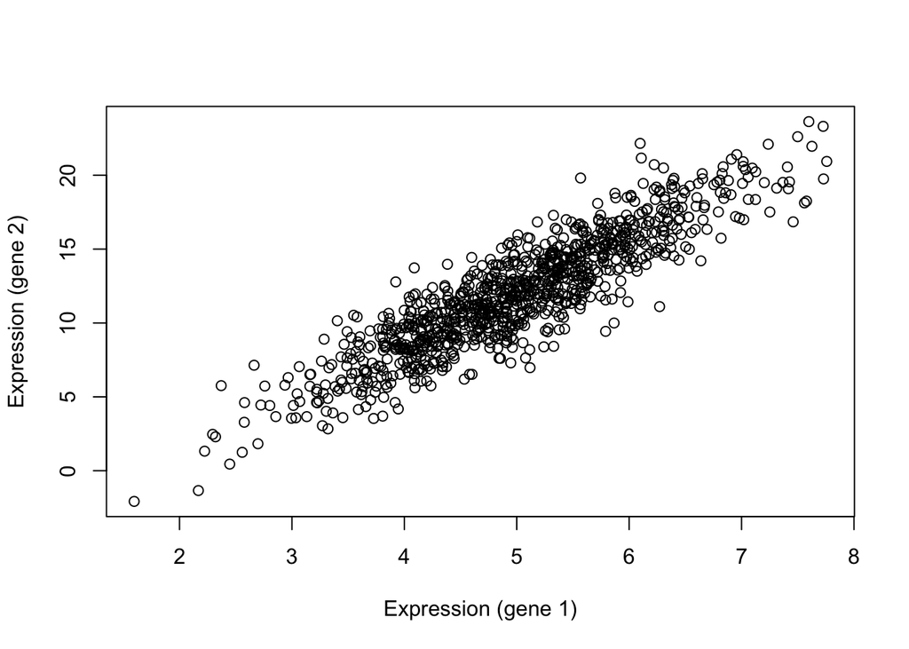

```r
Z = mvrnorm(1000, mu = c(5, 12), Sigma = Sig)
plot(Z[,1], Z[,2], xlab = "Expression (gene 1)",
     ylab = "Expression (gene 2)") # scatter plot expression of two correlated genes
```

```r
cor(Z, method = "pearson") # sample correlation coefficient
```

```
##           [,1]      [,2]
## [1,] 1.0000000 0.8969284
## [2,] 0.8969284 1.0000000
```

Next, we induce some dropouts as a function of the overall gene expression. We see for low expression there is a high probability of dropout.

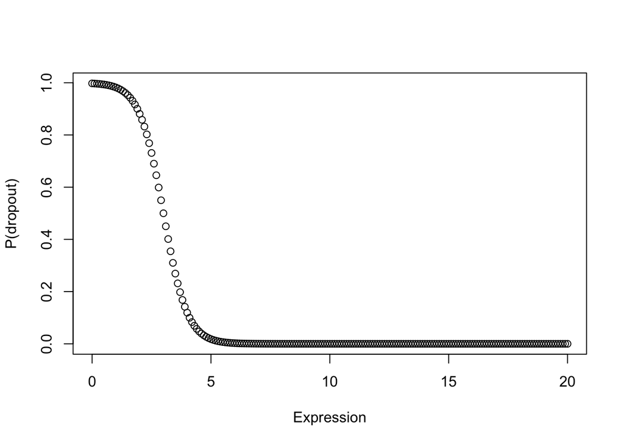

```r
# pick parameters for dropout
p.drop <- matrix(0, nrow=dim(Z)[1], ncol=dim(Z)[2]) # initalize a probability of a dropout
f <- function(x) {1 - 1 / (1+ exp(-(x-3)/.5 )) }
plot(seq(0, 20, by =.1), f(seq(0, 20, by =.1)),
     xlab = "Expression", ylab = "P(dropout)")
```

```r
p.drop <- f(abs(Z)) # probability of a dropout
head(Z)
```

```
##          [,1]      [,2]
## [1,] 6.116550 17.517522
## [2,] 4.842538  7.612033
## [3,] 4.612211 11.599148
## [4,] 4.171771  9.064237
## [5,] 5.563111 13.704509
## [6,] 4.003423  8.329937
```

```r
head(round(p.drop, 3))
```

```
##       [,1] [,2]
## [1,] 0.002    0
## [2,] 0.024    0
## [3,] 0.038    0
## [4,] 0.088    0
## [5,] 0.006    0
## [6,] 0.118    0
```

```r
# smaller the expression, higher the probablity of dropout
```

```r
Zvec <- as.vector(Z)
zz <- vector(mode="numeric", length(Zvec))
newp <- as.vector(p.drop)

for(i in 1:length(Zvec)){
  zz[i] <- sample(c(1, 0), 1, prob = c(1-newp[i], newp[i])) # 1 = original observation; 0 = dropout
}

Zind <- matrix(zz, nrow=dim(Z)[1], ncol=dim(Z)[2])
Zdrop <- matrix(ifelse(zz == 1, Zvec, 0 ), nrow=dim(Z)[1], ncol=dim(Z)[2]) # gene expression with dropouts
```

We can plot the pairwise gene expression with and without dropouts

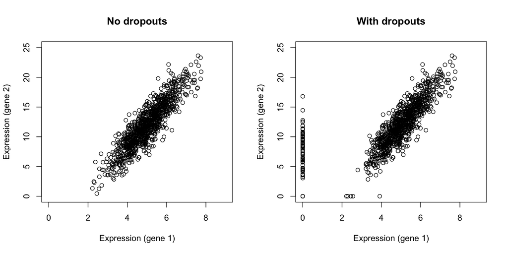

```r
par(mfrow=c(1,2))
plot(Z[,1], Z[,2], main = "No dropouts",
     xlim = c(0, 9), ylim = c(0, 25),
     xlab = "Expression (gene 1)", ylab = "Expression (gene 2)")
plot(Zdrop[,1], Zdrop[,2], main = "With dropouts",
     xlim = c(0, 9), ylim = c(0, 25),
     xlab = "Expression (gene 1)", ylab = "Expression (gene 2)")
```

We can calculate the sample correlation in the case without dropouts

```r
### sample correlation without dropout
cor(Z)
```

```
##           [,1]      [,2]
## [1,] 1.0000000 0.8969284
## [2,] 0.8969284 1.0000000
```

```r
# which matches
(nrow(Z) / (nrow(Z)-1)) *
  ((t(Z[,1]) %*% t(t(Z[,2]))) / nrow(Z) - (mean(Z[,1])*mean(Z[,2]))) /
          sqrt(var(Z[,1]) * var(Z[,2]))
```

```
##           [,1]
## [1,] 0.8969284
```

And we can calculate the sample correlation in the case with dropouts

```r
### sample correlation with dropout
cor(Zdrop)
```

```
##           [,1]      [,2]
## [1,] 1.0000000 0.7042052
## [2,] 0.7042052 1.0000000
```

```r
# matches
(nrow(Zdrop) / (nrow(Zdrop)-1) ) *
  ( (t(Zdrop[,1]) %*% t(t(Zdrop[,2]))) / nrow(Zdrop) - (mean(Zdrop[,1])*mean(Zdrop[,2])) ) /
  sqrt(var(Zdrop[,1]) * var(Zdrop[,2]))
```

```
##           [,1]
## [1,] 0.7042052
```

```r
par(mfrow=c(1,3))
### Least squares without dropouts
fit = lm(Z[,2] ~ Z[,1]); summary(fit)
```

```
##
## Call:
## lm(formula = Z[, 2] ~ Z[, 1])
##
## Residuals:
##     Min      1Q  Median      3Q     Max
## -5.4512 -1.1662  0.0056  1.1803  6.2188
##
## Coefficients:
##             Estimate Std. Error t value Pr(>|t|)
## (Intercept) -5.97084    0.28519  -20.94   <2e-16 ***
## Z[, 1]       3.59269    0.05606   64.08   <2e-16 ***
## ---
## Signif. codes:  0 '***' 0.001 '**' 0.01 '*' 0.05 '.' 0.1 ' ' 1
##
## Residual standard error: 1.736 on 998 degrees of freedom
## Multiple R-squared:  0.8045, Adjusted R-squared:  0.8043
## F-statistic:  4106 on 1 and 998 DF,  p-value: < 2.2e-16
```

```r
# same as
Z.mat <- cbind(rep(1, nrow(Z)), Z[,1])
solve(t(Z.mat) %*% t(t(Z.mat))) %*% t(Z.mat) %*% t(t(Z[,2]))
```

```
##           [,1]
## [1,] -5.970842
## [2,]  3.592685
```

```r
plot(Z, main = "No dropouts; least squares",
     xlim = c(0, 9), ylim = c(0, 25),
     xlab = "Expression (gene 1)", ylab = "Expression (gene 2)")
abline(coef(fit)[1], coef(fit)[2])


### Least squares with dropouts
fit = lm(Zdrop[,2] ~ Zdrop[,1]); summary(fit)
```

```
##
## Call:
## lm(formula = Zdrop[, 2] ~ Zdrop[, 1])
##
## Residuals:
##     Min      1Q  Median      3Q     Max
## -10.645  -1.931  -0.118   1.706  12.782
##
## Coefficients:
##             Estimate Std. Error t value Pr(>|t|)
## (Intercept)  4.02034    0.26824   14.99   <2e-16 ***
## Zdrop[, 1]   1.69057    0.05395   31.33   <2e-16 ***
## ---
## Signif. codes:  0 '***' 0.001 '**' 0.01 '*' 0.05 '.' 0.1 ' ' 1
##
## Residual standard error: 2.807 on 998 degrees of freedom
## Multiple R-squared:  0.4959, Adjusted R-squared:  0.4954
## F-statistic: 981.8 on 1 and 998 DF,  p-value: < 2.2e-16
```

```r
# same as
Zdrop.mat <- cbind(rep(1, nrow(Zdrop)), Zdrop[,1])
solve(t(Zdrop.mat) %*% t(t(Zdrop.mat))) %*% t(Zdrop.mat) %*% t(t(Zdrop[,2]))
```

```
##          [,1]
## [1,] 4.020338
## [2,] 1.690573
```

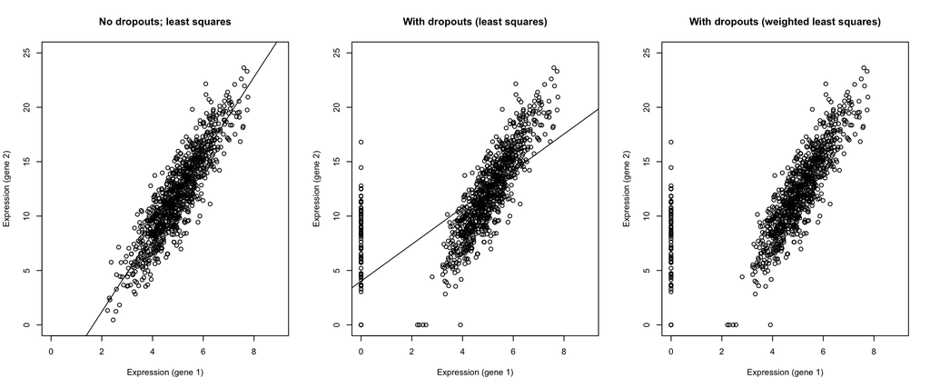

```r
plot(Zdrop, main = "With dropouts (least squares)",
     xlim = c(0, 9), ylim = c(0, 25),
     xlab = "Expression (gene 1)", ylab = "Expression (gene 2)")
abline(coef(fit)[1], coef(fit)[2])

### Weighted least squares with dropouts
w = apply(Zind * matrix(rbeta(nrow(Zind)*ncol(Zind), 1, 0.1),
                        nrow=nrow(Zind), ncol=ncol(Zind)), 1, FUN="prod")
# w[min(w) == w] <- 10^(-6)
W = w*diag(nrow(Z))

#coef.W <- solve(t(Zdrop.mat) %*% solve(W) %*% t(t(Zdrop.mat))) %*% t(Zdrop.mat) %*% solve(W) %*% t(t(Zdrop[,2])); coef.W
plot(Zdrop, main = "With dropouts (weighted least squares)",
     xlim = c(0, 9), ylim = c(0, 25),
     xlab = "Expression (gene 1)", ylab = "Expression (gene 2)")
```

```r
# abline(coef.W[1], coef.W[2])
```

```r
cor(Z) # sample correlation without dropout
```

```
##           [,1]      [,2]
## [1,] 1.0000000 0.8969284
## [2,] 0.8969284 1.0000000
```

```r
cor(Zdrop) # sample correlation with dropout
```

```
##           [,1]      [,2]
## [1,] 1.0000000 0.7042052
## [2,] 0.7042052 1.0000000
```

```r
boot::corr(Zdrop, w = w) # weight least squares to correct for dropout
```

```
## [1] 0.8832197
```